# Estimaciones

Probabilidad Aplicada

3602

# ¿Cómo podemos tener idea de si una variable se distribuye normalmente?

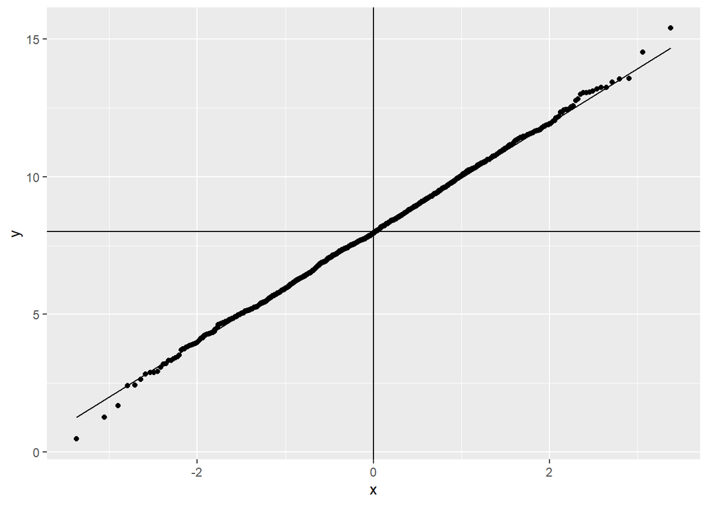

```r
g1 <- ggplot(insurance_ampliada, aes(sample = horas_sentado)) + geom_qq() + geom_qq_line() +
    geom_hline(yintercept = 8) + geom_vline(xintercept = 0)
g1
```

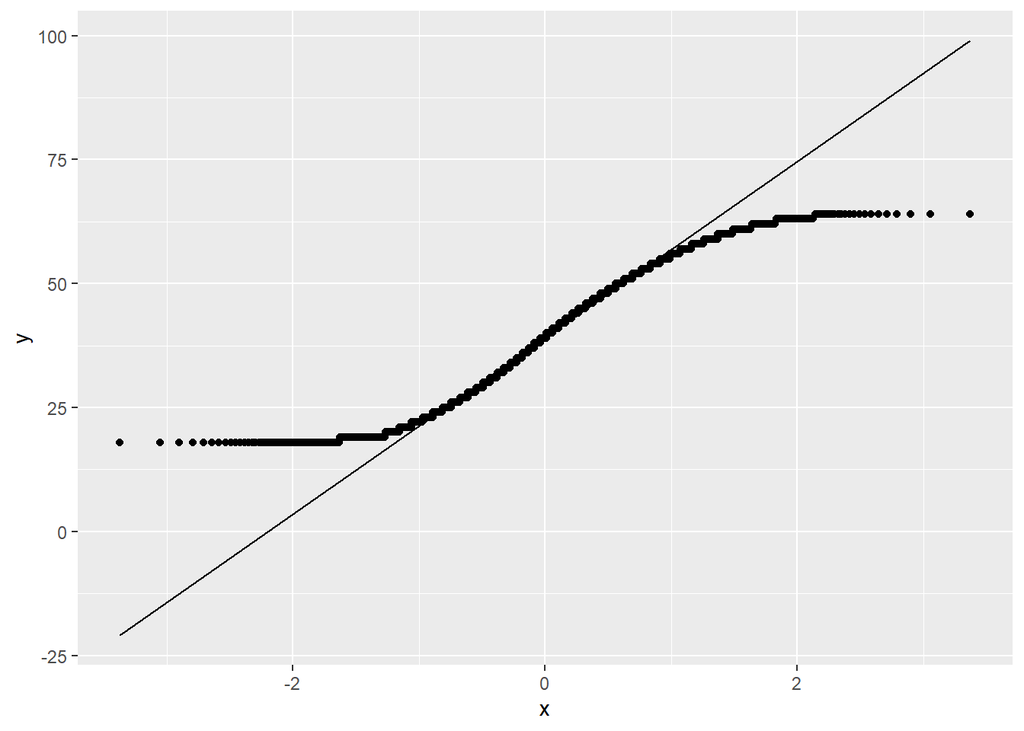

```r
g2 <- ggplot(insurance_ampliada, aes(sample = edad)) + geom_qq() + geom_qq_line()
g2
```

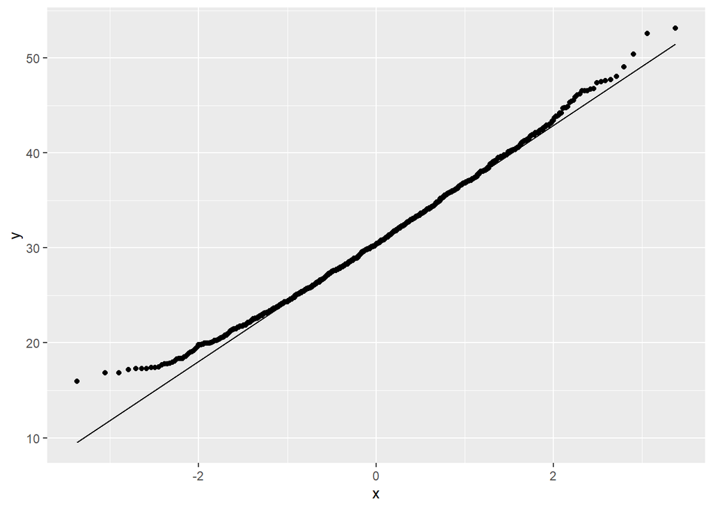

```r
g3 <- ggplot(insurance_ampliada, aes(sample = IMC)) + geom_qq() + geom_qq_line()
g3
```

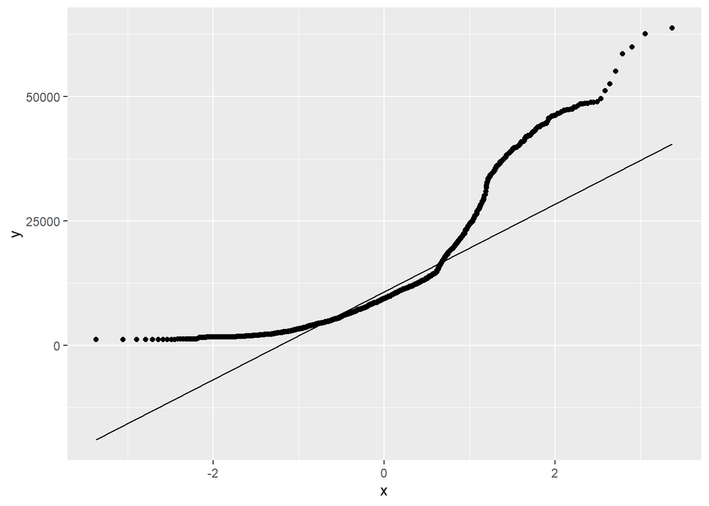

```r
g4 <- ggplot(insurance_ampliada, aes(sample = prima)) + geom_qq() + geom_qq_line()
g4
```

```r
growth <- read_csv("E:/INSPT-UTN/2023/PA/PA con R/Materiales/Unidad 1-Estadística descriptiva/05-Estimaciones/growth.csv")
```

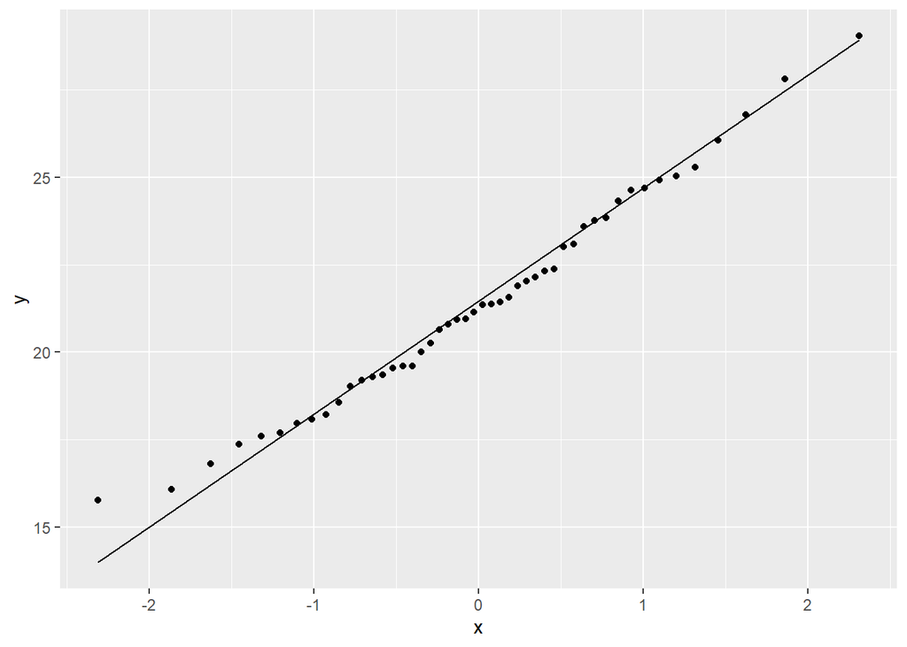

```r
g5 <- ggplot(growth, aes(sample = gain)) + geom_qq() + geom_qq_line()
g5
```

```r
compensation <- read_csv("E:/INSPT-UTN/2023/PA/PA con R/Materiales/Unidad 1-Estadística descriptiva/05-Estimaciones/compensation.csv")
```

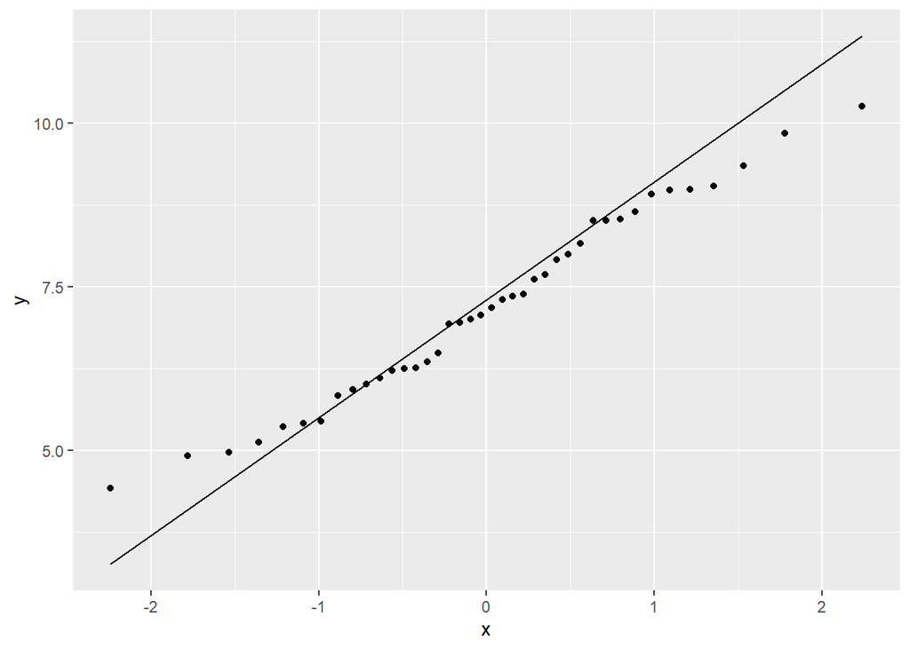

```r
g6 <- ggplot(compensation, aes(sample = Root)) + geom_qq() + geom_qq_line()
g6
```

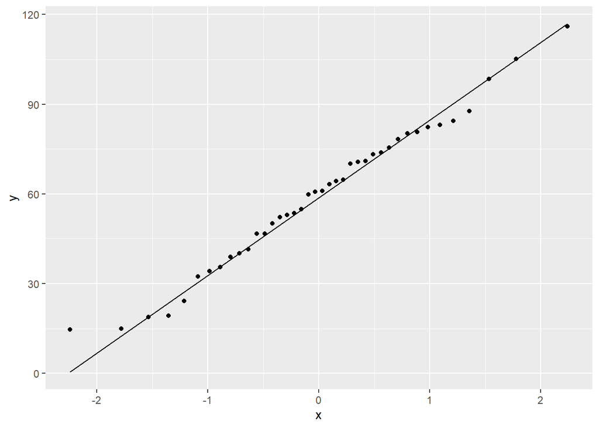

```r
g7 <- ggplot(compensation, aes(sample = Fruit)) + geom_qq() + geom_qq_line()
g7
```

Para las bandas de confianza, utilizar la librería *qqplotr* y las geometrias *geom_qq_band*, *stat_qq_line*,*stat_qq_point*

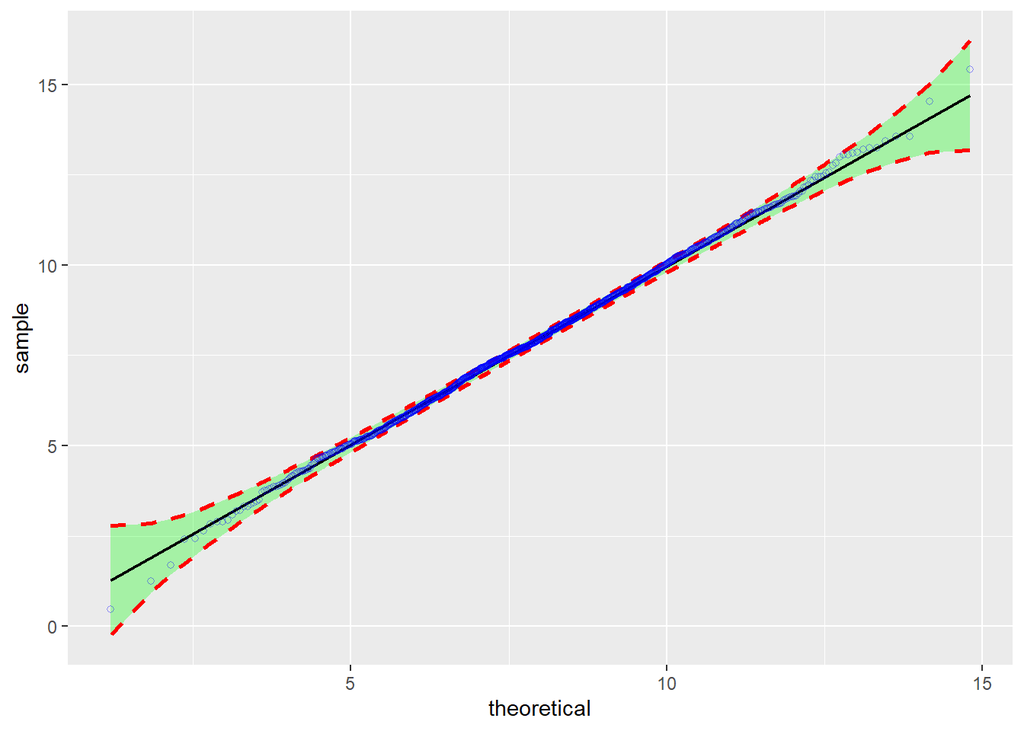

```r
g8 <- ggplot(insurance_ampliada, aes(sample = horas_sentado)) + geom_qq_band(color = "red",
    fill = "green", alpha = 0.3, linetype = "dashed", linewidth = 1) + stat_qq_line() +
    stat_qq_point(color = "blue", shape = 21, alpha = 0.4)
g8
```

## Estimación puntual para la media

```r
mean(insurance_ampliada$horas_sentado)
```

```
## [1] 7.995665
```

```r
sd(insurance_ampliada$horas_sentado)
```

```
## [1] 2.01822
```

## Estimación por intervalos de confianza para la media

Supongamos que la base insurance_ampliada lleva el registro de una población.

Vamos a tomar una muestra aleatoria simple de 100 registros.

Para este muestreo usamos la función **slice_sample** de **dplyr**:

```r
m1 <- insurance_ampliada %>%
    slice_sample(n = 100, replace = F)
m1
```

```
## # A tibble: 100 x 9
##       ID  edad genero      IMC hijos fumador region    prima horas_sentado
##    <int> <dbl> <chr>     <dbl> <dbl> <chr>   <chr>     <dbl>         <dbl>
##  1   871    50 Masculino  36.2     0 no      suroeste  8458.          9.92
##  2   549    25 Femenino   28.6     0 no      noreste   3214.          8.96
##  3   204    27 Femenino   36.1     0 yes     sureste  37134.         11.0
##  4  1119    33 Masculino  35.8     1 yes     sureste  38283.         12.1
##  5  1299    33 Masculino  27.5     2 no      noroeste  5261.          8.03
##  6   207    59 Masculino  26.4     0 no      sureste  11743.          5.27
##  7     7    46 Femenino   33.4     1 no      sureste   8241.          8.33
##  8    68    40 Masculino  26.3     1 no      noroeste  6389.          8.55
##  9   360    18 Femenino   20.8     0 no      sureste   1608.          7.32
## 10   823    18 Femenino   31.1     0 no      sureste   1622.          8.12
## # i 90 more rows
```

Construimos un intervalo de confianza para la media del 90% con esta muestra:

El intervalo de confianza se calcula como $[L_i;L_s]$ donde $L_i,L_s=\overline{x} \pm z \cdot \dfrac{s}{\sqrt{n}}$

$\overline{x}:$ media muestral.

$z:$ es el cuantil de la distribución normal correspondiente al nivel de confianza fijado previamente por el analista.

$s:$ desvio muestral.

$n:$ tamaño muestral.

A la cantidad $\dfrac{s}{\sqrt{n}}$ se la denomina *Error estándar*

En nuestro caso, el tamaño de la muestra es

```r
n = 100
n
```

```
## [1] 100
```

Calculamos la media muestral:

```r
x <- mean(m1$horas_sentado)
x
```

```
## [1] 8.226258
```

```r
s <- sd(m1$horas_sentado)
s
```

```
## [1] 1.972575
```

Fijamos el nivel de confianza en un $90\%$. Esto significa que necesitamos que de cada 100 veces que tomemos una muestra y construyamos nuestro intervalo, el valor de media poblacional (verdadero y desconocido) esté contenido en 90 de ellos.

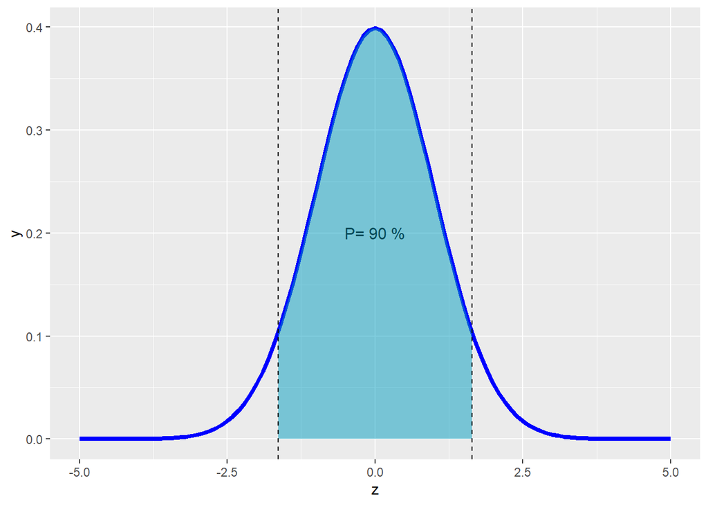

Una vez que tenemos fijada la probalidad que llamamos nivel de confianza, tenemos que tener en cuenta que esta probablidad deja un $10\%$ en repartidos en las dos colas de la distribución normal. Entonces, tenemos un $5\%$ en cada cola, tal como muestra el siguiente gráfico.

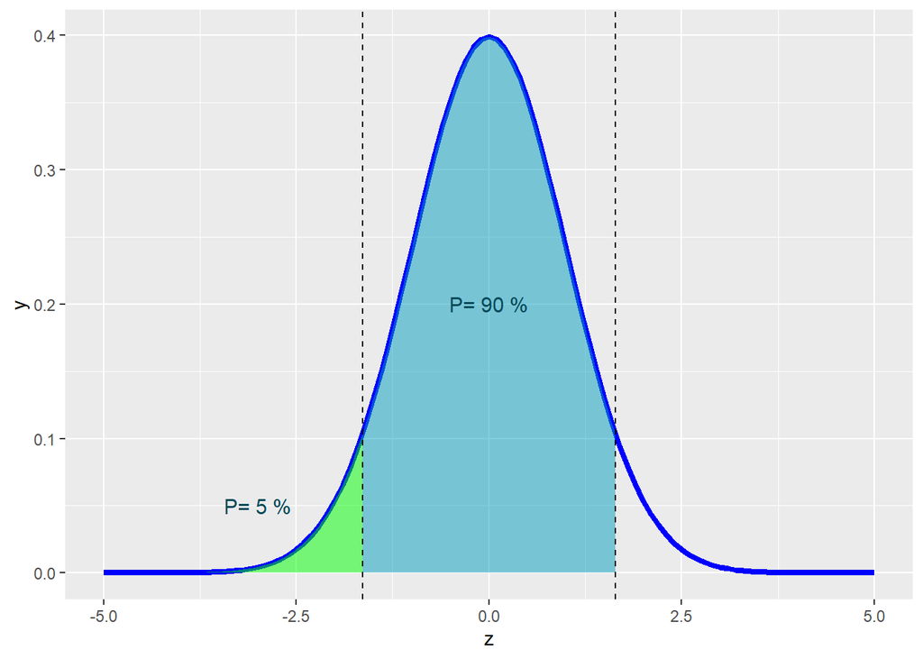

Con esto en mente, ahora sabemos qué cuantil debemos determinar. Es el que acumula a izquierda, un $95\%$ o $0.95$

```r
z_90 <- qnorm(0.95)
z_90
```

```
## [1] 1.644854
```

Con todos estos datos, ya podemos calcular los límites de nuestro intervalo:

```r
L_i <- x - z_90 * (s/sqrt(n))
L_i
```

```
## [1] 7.901798
```

```r
L_s <- x + z_90 * (s/sqrt(n))
L_s
```

```
## [1] 8.550717
```

Calculamos la media poblacional (y el desvío) para poder verificar que cae en el intervalo de confianza construido

```r
mu <- mean(insurance_ampliada$horas_sentado)
mu
```

```
## [1] 7.995665
```

```r
sigma <- sd(insurance_ampliada$horas_sentado)
sigma
```

```
## [1] 2.01822
```

Ahora la idea será repetir esto muchas veces. Tenemos que crear una simulacion aleatoria

```r
# Número de muestras y tamaño de cada muestra
num_muestras <- 100
n <- 10

# Inicializamos un dataframe vacío para almacenar los resultados
resultados <- data.frame(Muestra = 1:num_muestras, Limite_Inferior = numeric(num_muestras),
    Limite_Superior = numeric(num_muestras), Medias_muestrales = numeric(num_muestras))

# Fijamos el Nivel de confianza (por ejemplo, 90%)
confianza <- 0.9

# Realizamos el proceso de muestreo y cálculo del intervalo de confianza para
# cada muestra
for (i in 1:num_muestras) {
    # Tomamos una muestra aleatoria de tamaño 'tamano_muestra' n de la variable
    muestra <- sample(insurance_ampliada$horas_sentado, size = n)

    # Calculamos la media y el desvío de la muestra
    x <- mean(muestra)
    s <- sd(muestra)

    # Valor crítico para la distribución normal estándar
    z <- qnorm(1 - (1 - confianza)/2)

    # Calculamos el error estándar de la media
    error_estandar_media <- s/sqrt(n)

    # Calculamos el intervalo de confianza
    limite_inferior <- x - z * error_estandar_media
    limite_superior <- x + z * error_estandar_media

    # Almacenamos los resultados en el dataframe
    resultados[i, ] <- c(i, limite_inferior, limite_superior, x)
}
```

Ahora queremos saber si en cada intervalo de confianza construído la media poblacional está incluído…

```r
# Creamos una función para verificar si la media poblacional está contenida en
# el intervalo

verificar_inclusion <- function(row) {
    if (row["Limite_Inferior"] <= mu && row["Limite_Superior"] >= mu) {
        return("si")
    } else {
        return("no")
    }
}

# esta función inspeccionará cada fila (row) de nuestro dataframe 'resultados'.
# Y agregaremos a nuestro dataframe una columna 'Inclusion' al dataframe
# resultados.
resultados$Inclusion <- apply(resultados, 1, verificar_inclusion)
```

¿En cuántos de estos intervalos está incluído el valor verdadero?

```r
tabla <- resultados %>%
    dplyr::group_by(Inclusion) %>%
    dplyr::summarise(cantidad = n())
tabla
```

```
## # A tibble: 2 x 2
##   Inclusion cantidad
##   <chr>        <int>
## 1 no              11
## 2 si              89
```

¿Coincide con lo esperado?

Grafiquemos los intervalos, las medias muestrales y la media poblacional…

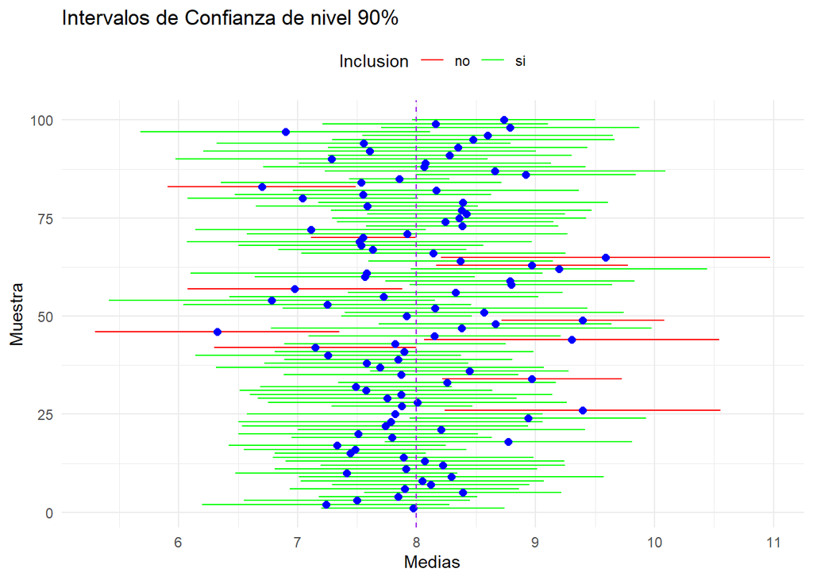

```r
g10 <- ggplot(resultados, aes(x = (Limite_Superior + Limite_Inferior)/2, y = Muestra,
    color = Inclusion)) + geom_segment(aes(xend = Limite_Inferior, yend = Muestra),
    linetype = "solid", linewidth = 0.5) + geom_segment(aes(xend = Limite_Superior,
    yend = Muestra), linetype = "solid", linewidth = 0.5) + geom_point(aes(x = Medias_muestrales,
    y = Muestra), color = "blue", size = 2) + geom_vline(xintercept = mu, linetype = "dashed",
    color = "purple") + scale_color_manual(values = c(si = "green", no = "red")) +
    labs(title = "Intervalos de Confianza de nivel 90%", x = "Medias", y = "Muestra") +
    theme_minimal() + theme(legend.position = "top")

g10
```

## Estimación por intervalo de confianza para la proporción

El intervalo de confianza se calcula como $[L_i;L_s]$ donde $L_i,L_s=\hat{p} \pm z \cdot \sqrt{\dfrac{\hat{p} \hat {q}}{{n}}}$

$\hat{p}:$ proporción de éxitos muestral. $\hat{q}:$ proporción de fracasos muestral.

$z:$ es el cuantil de la distribución normal correspondiente al nivel de confianza fijado previamente por el analista.

$n:$ tamaño muestral.

**Ejemplo de estimación por intervalo de confianza para la proporción**

En una muestra aleatoria de $n=500$ familias que están suscriptas a plataformas en la Ciudad Autónoma de Buenos Aires, se encuentran que $x=340$ están suscriptas a Netflix. Calcular el intervalo de confianza del $95\%$ para la porporción real de familias que están suscriptas a Netflix en CABA.

## La distribución Chi (o Ji) Cuadrado

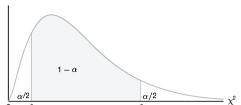

Distribución Chi-Cuadrado

R: Distribución ji-Cuadrada.

| Función en R | Sirve para |
| --- | --- |
| **dchisq**(x, df, ncp=0, log = F) | Devuelve resultados de la función de densidad. |
| **pchisq**(q, df, ncp=0, lower.tail = T, log.p = F) | Devuelve resultados de la función de distribución acumulada. |
| **qchisq**(p, df, ncp=0, lower.tail = T, log.p = F) | Devuelve resultados de los cuantiles de la ji-Cuadrada. |
| **rchisq**(n, df, ncp=0) | Devuelve un vector de valores de la ji-Cuadrada aleatorios. |

Los argumentos que podemos pasar a las funciones expuestas en la anterior tabla, son:

$x, q$: Vector de cuantiles.

$p$: Vector de probabilidades.

$n$: Números de observaciones.

$df$: Grados de libertad.

$lower.tail$: Parámetro booleano, si es TRUE (por defecto), las probabilidades son P[X ≤ x], de lo contrario, P [X > x].

Ejercicios.

1. ¿Cuál es el valor que tiene la ji-cuadrado con un área de cola de $0.900$ y $5$ grados de libertad?
2. $P(\chi^2 < x) = 0.999$ con $20$ grados de libertad.
3. $P(\chi^2 \geq 18.49)$ con $30$ grados de libertad.

## Estimación por intervalo de confianza para el desvío (o la varianza como cuadrado del desvío)

El intervalo de confianza se calcula como $[L_i;L_s]$ donde:

$L_i=\sqrt{\dfrac{(n-1)s^2}{\chi^2_{1-\alpha/2}}}$

$L_s=\sqrt{\dfrac{(n-1)s^2}{\chi^2_{\alpha/2}}}$

$n$ tamaño de muestra

$S$ desvío muestral

$n-1$ son los grados de libertad para la chi.

$\chi^2_{1-\alpha/2}$ y $\chi^2_{\alpha/2}$ son las chi cuadradas de probabilidades $1-\alpha/2$ y $\alpha/2$ a izquierda (con lower.tail=T en R).